# Problem set 4: Models

# Instructions

- You will do your work in this `Rmarkdown` document but will submit all your answers on Canvas
- *very important*: As you move through the document, make sure to run all code chunks (grey bits) that already have code in them
- Write your own code in the empty code chunks
- Useful shortcuts:
  - to run all the code in a specific code chunk, press the green right-facing triangle at the top right of the code chunk
  - to run all *prior* code chunks, press the downward-facing gray triangle at the top right of the code chunk

```r
library(tidyverse)
library(socviz)
library(broom)
library(palmerpenguins)
library(ggcorrplot)
library(fivethirtyeight)
library(juanr)
```

# Task 1: Correlations

Look at the following example of a data analysis task:

> Amazon using your past browsing history to recommend new purchases.

**Q1: Identify the treatment and outcome variable in this example**

Now, run the code to look at the correlation below:

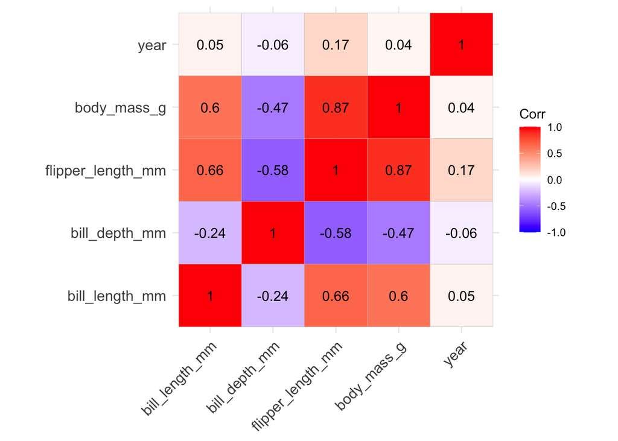

```r
penguins %>%
  # correlation only works with numeric columns; keep only those
  select(where(is.numeric)) %>%
  # the cor() function doesn't take NA; drop them all
  drop_na() %>%
  # get the correlation
  cor() %>%
  # plot the correlation
  ggcorrplot(lab = TRUE)
```

**Q2: Interpret the correlation between bill length (in millimeters), and bill depth (in millimeters)**

# Task 2: Aid and conflict

One of the big questions in international relations is whether giving aid to countries that are experiencing civil wars can help reduce conflict or, instead, [make things worse](https://www.independent.co.uk/voices/syria-sick-children-cancer-humanitarian-aid-bashar-al-assad-putin-war-worse-a8132056.html). Does foreign aid make a country more peaceful or more violent?

Let’s look at some data I made-up to simulate this claim. Each row is a country, and `conflict` is the amount of violence that country is experiencing in a given year (combat deaths per 100,000 people). `funding` is how much money, in millions of dollars, that country receives. `corruption` tells you whether country scores high or low on corruption.

```r
aid_conf = read_csv("https://www.dropbox.com/s/l3oyr6knrv5myvp/sim-aid-conflict.csv?dl=1")
aid_conf
```

```
## # A tibble: 1,000 × 3
##    conflict funding corruption
##       <dbl>   <dbl> <chr>
##  1    32.5     37.2 High Corruption
##  2    30.8     42.6 Low Corruption
##  3    41.4     72.2 Low Corruption
##  4    44.4     47.6 Low Corruption
##  5     5.37    48.6 Low Corruption
##  6    58.0     74.8 High Corruption
##  7    49.3     54.1 Low Corruption
##  8    89.6     25.5 Low Corruption
##  9    60.0     35.1 Low Corruption
## 10    41.0     39.1 High Corruption
## # … with 990 more rows
```

Fit a model to explore whether changes in foreign aid are associated with changes in conflict.

**Q3: rounding to the first decimal place, what is the coefficient on aid?**

This is the overall relationship, across all countries, but countries are different in many ways and the effect of aid might differ across different kinds of countries.

Fit the same model as above, except this time you will do it **separately** for low corruption and high corruption countries (so: two models total).

**Q4: Interpret the coefficient on aid for LOW corruption countries**

**Q5: Interpret the coefficient on aid for HIGH corruption countries**

Finally, make a scatterplot of the relationship between `conflict` and `funding`, with a trend line so you can see the general pattern. Use `facet_wrap` to create separate plots for countries with low and high corruption. Add labels and a theme.

**Q6: right click the graph –> “save image as” –> and save it somewhere on your computer. You will need to submit the plot!**

**Q7: What does the difference in pattern across high and low corruption countries tell you about the relationship between aid and conflict?**

# Task 3: Regressing with categories

Look at the `bonica` dataset again from `juanr`, which provides candidate-level information on campaign fundraising.

```r
bonica
```

```
## # A tibble: 9,787 × 13
##    cycle name                party dwnom1 state district seat   incumbent gender
##    <dbl> <chr>               <chr>  <dbl> <chr> <chr>    <chr>  <chr>     <chr>
##  1  2018 Van Risseghem, Ant… R         NA WY    WYS18    senate challeng… M
##  2  2018 Holtz, John         R         NA WY    WYS18    senate challeng… M
##  3  2018 Hardy, Charles E    R         NA WY    WYS18    senate challeng… M
##  4  2018 De La Fuente, Roqu… D         NA WY    WYS18    senate challeng… M
##  5  2018 Miller, Rod         R         NA WY    WY01     house  challeng… M
##  6  2018 Stanley, Blake      R         NA WY    WY01     house  challeng… M
##  7  2018 Cummings, Daniel C… I         NA WY    WY01     house  open seat M
##  8  2018 Helm, Travis        D         NA WY    WY01     house  challeng… M
##  9  2018 Hunter, Greg        D         NA WY    WY01     house  challeng… M
## 10  2018 Hall, Justin Haywa… I          0 WV    WVS18    senate challeng… M
## # … with 9,777 more rows, and 4 more variables: num_distinct_donors <dbl>,
## #   total_receipts <dbl>, contribs_from_candidate <dbl>,
## #   total_disbursements <dbl>
```

```r
?bonica
```

Run a regression where you look at how candidate `gender` impacts their ability to raise money (`total_receipts`). Note: remember that to see what values a specific variable takes on, you can use: `data %>% distinct(variable)`. Also note: some candidates have a gender listed as “U”. U = unknown. The reason their gender is unknown is the creators of the dataset used an algorithm to try to guess candidates’ gender based on their name, rather than manually code.

**Q8: Using SPECIFIC language, interpret the coefficient estimate for the INTERCEPT**

**Q9: Based on the above, which gender category performed the worst at campaign fundraising?**